# pre-final

```r
r2d3(data = cluster_plot_data[[2]], script = "cluster_chart.js",viewer ="internal")
```

[interactive chart not shown]

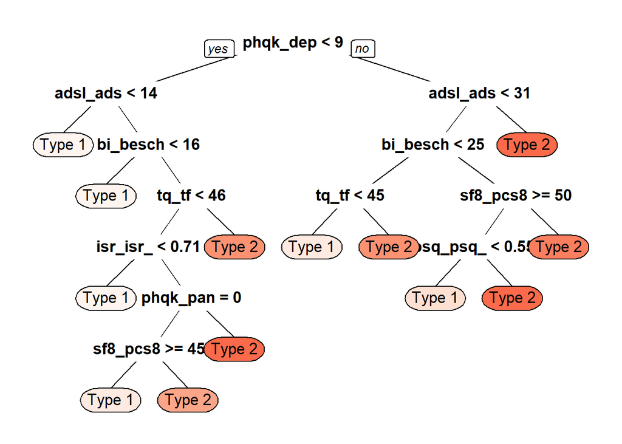

```r
createDT(hk2_labels,removeNA)
```

```r
#applyrf(hk2_labels,2,1500,5)

# Orclus
set.seed(123)
orclus_res_k2 <- orclus(x = df_noCorr_scaled,k=num_clusters,l = 25, k0 = 20)
```

```
## iteration         : 1
## Initialization with 20 clusters
## Actual Subspace dimension : 73
## New number of clusters    : 10
##
## iteration         : 2
## Actual Subspace dimension : 53
## New number of clusters    : 5
##
## iteration         : 3
## Actual Subspace dimension : 38
## New number of clusters    : 2
##
## iteration         : 4
## Actual Subspace dimension : 28
## New number of clusters    : 2
##
## iteration         : 5
## Actual Subspace dimension : 25
## New number of clusters    : 2
##
## Final reassigment...
```

```r
ok2_labels <- orclus_res_k2$cluster
cluster_plot_data<-getPlotData("Orclus",ok2_labels,num_clusters)
r2d3(data = cluster_plot_data[[1]], script = "cluster_chart.js",viewer ="internal")
```

[interactive chart not shown]

```r
r2d3(data = cluster_plot_data[[2]], script = "cluster_chart.js",viewer ="internal")
```

[interactive chart not shown]

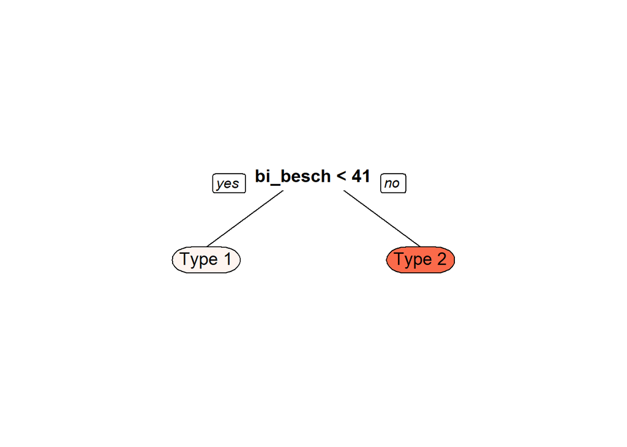

```r
createDT(ok2_labels,removeNA)
```

```r
# applyrf(ok2_labels,2,1500,5)

# Proclus
set.seed(123)
removeNA <- 1
p2_labels<-c()
for(i in k2_cluster1){
  p2_labels[i] <- 1
}
for(i in k2_cluster2){

  p2_labels[i]<- 2
}
cluster_plot_data<-getPlotData("Proclus",p2_labels,num_clusters)
r2d3(data = cluster_plot_data[[1]], script = "cluster_chart.js",viewer ="internal")
```

[interactive chart not shown]

```r
r2d3(data = cluster_plot_data[[2]], script = "cluster_chart.js",viewer ="internal")
```

[interactive chart not shown]

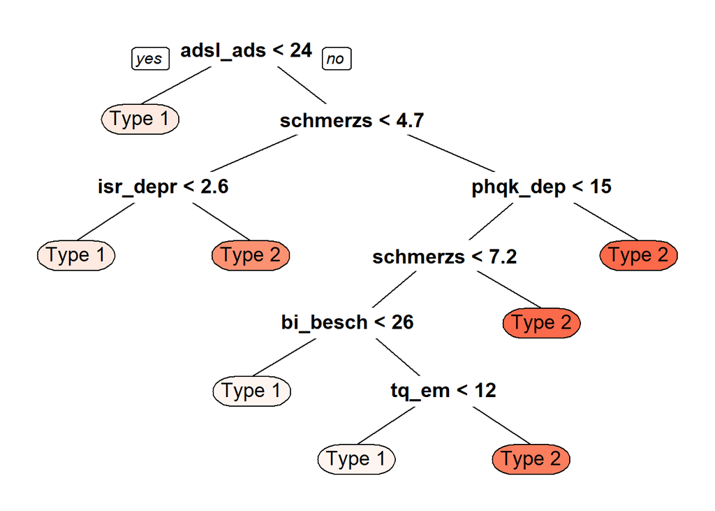

```r
createDT(p2_labels,removeNA)
```

```r
# applyrf(p2_labels,2,,)
```

# Fetching labels for k=4

```r
set.seed(123)
removeNA<- 0
num_clusters<- 4

# k means
set.seed(123)
kmclust4 <- kmeans(df_noCorr_scaled,num_clusters, nstart=50,iter.max = 15)
km4_labels <- kmclust4$cluster
cluster_plot_data<-getPlotData("K-means",km4_labels,num_clusters)
r2d3(data = cluster_plot_data[[1]], script = "cluster_chart.js",viewer ="internal")
```

[interactive chart not shown]

```r
r2d3(data = cluster_plot_data[[2]], script = "cluster_chart.js",viewer ="internal")
```

[interactive chart not shown]

```r
r2d3(data = cluster_plot_data[[3]], script = "cluster_chart.js",viewer ="internal")
```

[interactive chart not shown]

```r
r2d3(data = cluster_plot_data[[4]], script = "cluster_chart.js",viewer ="internal")
```

[interactive chart not shown]

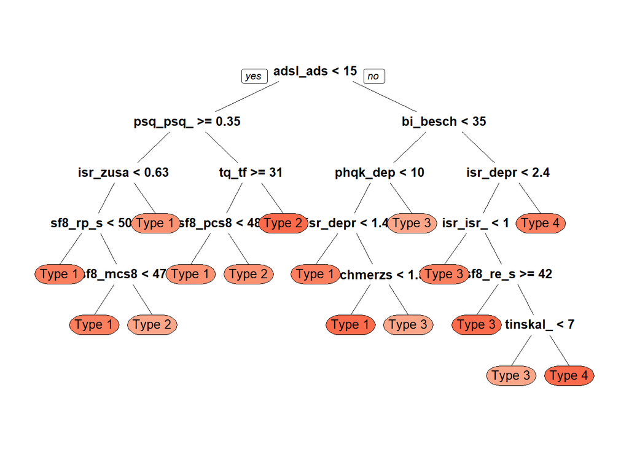

```r
createDT(km4_labels,removeNA)
```

```r
# applyrf(km4_labels,2,1500,5)

# Hierarchical
set.seed(123)
h4_labels<-cutree(hc,k=num_clusters)
cluster_plot_data<-getPlotData("Hierarchical Clustering",h4_labels,num_clusters)
r2d3(data = cluster_plot_data[[1]], script = "cluster_chart.js",viewer ="internal")
```

[interactive chart not shown]

```r
r2d3(data = cluster_plot_data[[2]], script = "cluster_chart.js",viewer ="internal")
```

[interactive chart not shown]

```r
r2d3(data = cluster_plot_data[[3]], script = "cluster_chart.js",viewer ="internal")
```

[interactive chart not shown]

```r
r2d3(data = cluster_plot_data[[4]], script = "cluster_chart.js",viewer ="internal")
```

[interactive chart not shown]

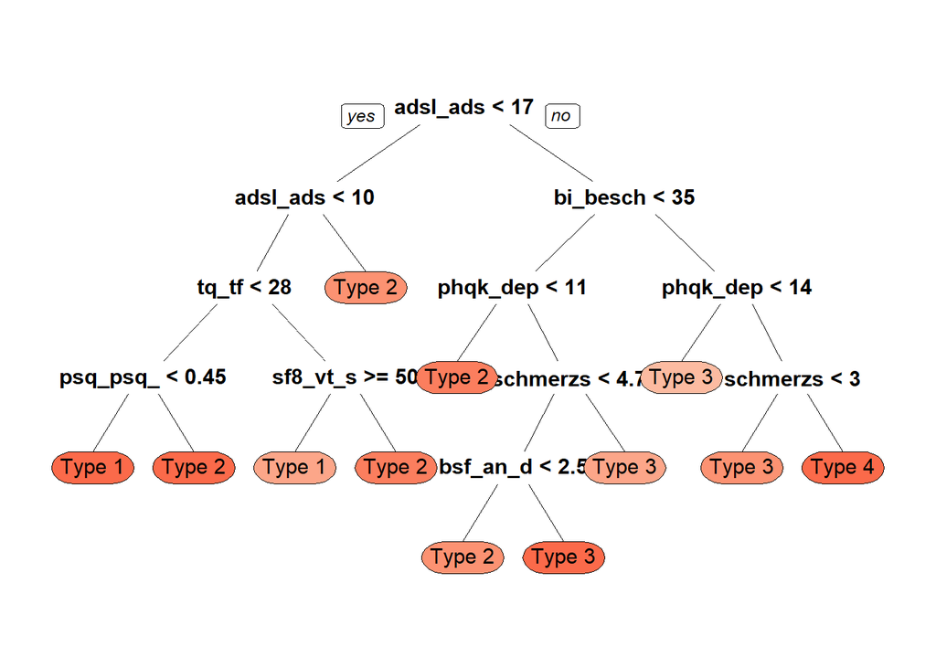

```r
createDT(h4_labels,removeNA)
```

```r
# applyrf(h4_labels,2,1500,5)
# HK means

#PCA- KMEANS
set.seed(123)
pckmclust4 <- kmeans(df_PC,num_clusters, nstart=50,iter.max = 15)
pckm4_labels <- pckmclust4$cluster
cluster_plot_data<-getPlotData("PCA K-means",pckm4_labels,num_clusters)
r2d3(data = cluster_plot_data[[1]], script = "cluster_chart.js",viewer ="internal")
```

[interactive chart not shown]

```r
r2d3(data = cluster_plot_data[[2]], script = "cluster_chart.js",viewer ="internal")
```

[interactive chart not shown]

```r
r2d3(data = cluster_plot_data[[3]], script = "cluster_chart.js",viewer ="internal")
```

[interactive chart not shown]

```r
r2d3(data = cluster_plot_data[[4]], script = "cluster_chart.js",viewer ="internal")
```

[interactive chart not shown]

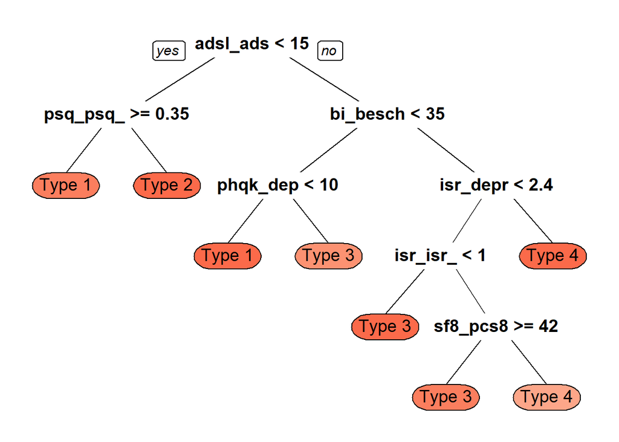

```r
createDT(pckm4_labels,removeNA)
```

```r
# applyrf(pckm2_labels,2,1500,5)

#HK Means
set.seed(123)
res.hk4 <-hkmeans(df_noCorr_scaled, num_clusters)
hk4_labels <- res.hk4$cluster
cluster_plot_data<-getPlotData("Hierarchical K-means",hk4_labels,num_clusters)
r2d3(data = cluster_plot_data[[1]], script = "cluster_chart.js",viewer ="internal")
```

[interactive chart not shown]

```r
r2d3(data = cluster_plot_data[[2]], script = "cluster_chart.js",viewer ="internal")
```

[interactive chart not shown]

```r
r2d3(data = cluster_plot_data[[3]], script = "cluster_chart.js",viewer ="internal")
```

[interactive chart not shown]

```r
r2d3(data = cluster_plot_data[[4]], script = "cluster_chart.js",viewer ="internal")
```

[interactive chart not shown]

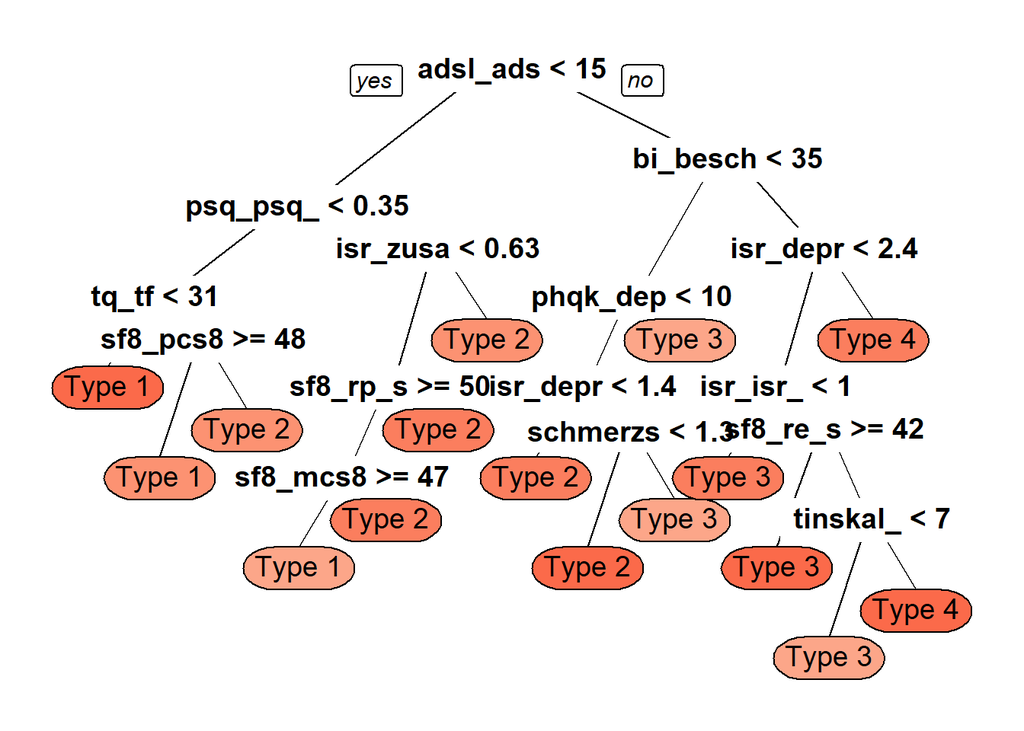

```r
createDT(hk4_labels,removeNA)
```

```r
# applyrf(df_allF_hk4_labeled,4,,)

#Orclus
set.seed(123)
orclus_res_k4 <- orclus(x = df_noCorr_scaled,k=num_clusters,l = 20, k0 = 31)
```

```
## iteration         : 1
## Initialization with 31 clusters
## Actual Subspace dimension : 73
## New number of clusters    : 16
##
## iteration         : 2
## Actual Subspace dimension : 47
## New number of clusters    : 8
##
## iteration         : 3
## Actual Subspace dimension : 30
## New number of clusters    : 4
##
## iteration         : 4
## Actual Subspace dimension : 20
## New number of clusters    : 4
##
## Final reassigment...
```

```r
ok4_labels <- orclus_res_k4$cluster
cluster_plot_data<-getPlotData("Orclus",ok4_labels,num_clusters)
r2d3(data = cluster_plot_data[[1]], script = "cluster_chart.js",viewer ="internal")
```

[interactive chart not shown]

```r
r2d3(data = cluster_plot_data[[2]], script = "cluster_chart.js",viewer ="internal")
```

[interactive chart not shown]

```r
r2d3(data = cluster_plot_data[[3]], script = "cluster_chart.js",viewer ="internal")
```

[interactive chart not shown]

```r
r2d3(data = cluster_plot_data[[4]], script = "cluster_chart.js",viewer ="internal")
```

[interactive chart not shown]

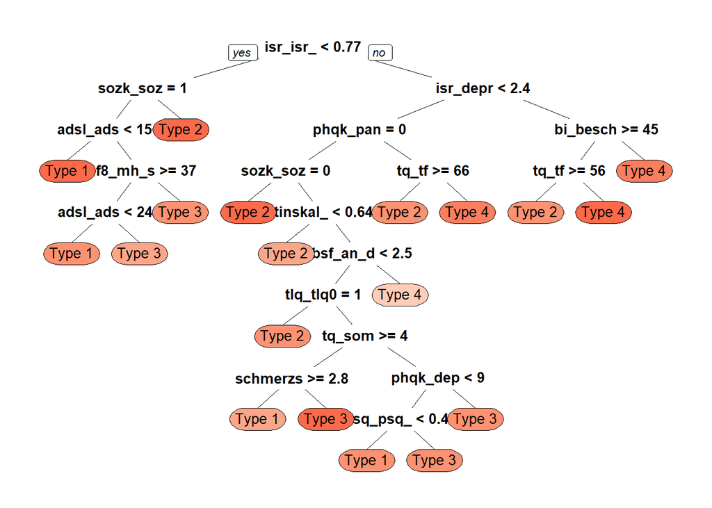

```r
createDT(ok4_labels,removeNA)
```

```r
# applyrf(ok4_labels,2,1500,5)

# Proclus
set.seed(123)
removeNA <- 1
p4_labels<-c()
for(i in k4_cluster1){
  p4_labels[i] <- 1
}
for(i in k4_cluster2){

  p4_labels[i]<- 2
}
for(i in k4_cluster3){
  p4_labels[i] <- 3
}
for(i in k4_cluster4){

  p4_labels[i]<- 4
}
cluster_plot_data<-getPlotData("Proclus",p4_labels,num_clusters)
r2d3(data = cluster_plot_data[[1]], script = "cluster_chart.js",viewer ="internal")
```

[interactive chart not shown]

```r
r2d3(data = cluster_plot_data[[2]], script = "cluster_chart.js",viewer ="internal")
```

[interactive chart not shown]

```r
r2d3(data = cluster_plot_data[[3]], script = "cluster_chart.js",viewer ="internal")
```

[interactive chart not shown]

```r
r2d3(data = cluster_plot_data[[4]], script = "cluster_chart.js",viewer ="internal")
```

[interactive chart not shown]

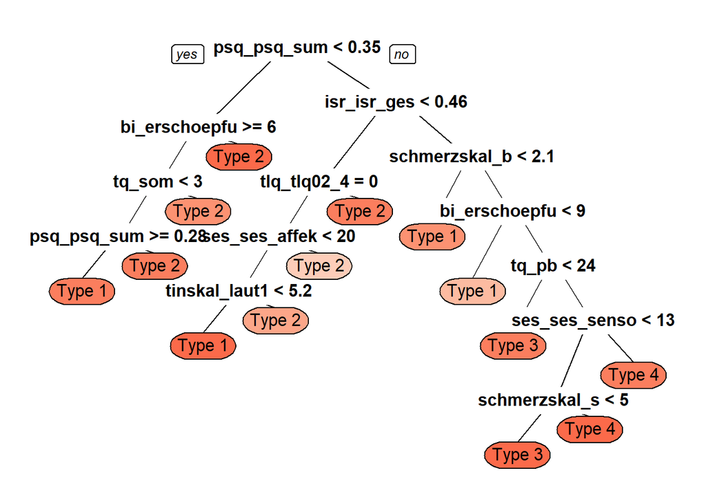

```r
createDT(p4_labels,removeNA)
```

```r
# applyrf(p4_labels,2,1500,5)
```

Evaluation Dunn Index: It is the ratio of minimum of this pairwise distance as the inter-cluster separation (min.separation) to the maximal intra-cluster distance (i.e maximum diameter) as the intra-cluster compactness.If the data set contains compact and well-separated clusters, the diameter of the clusters is expected to be small and the distance between the clusters is expected to be large. Thus, Dunn index should be maximized. Connectivity: corresponds to what extent items are placed in the same cluster as their nearest neighbors in the data space. The connectivity has a value between 0 and infinity and should be minimized. Compactness or cluster cohesion: Measures how close are the objects within the same cluster. A lower within-cluster variation is an indicator of a good compactness (i.e.a good clustering). Smaller values indicate a better clustering structure.

```r
evaluate<-function(labels){

  result_set<-vector("list", 3)
  result_set[1]<-dunn(clusters = labels, Data=df_allF_scaled)
  result_set[2]<-connectivity(distance = NULL, labels, Data = df_allF_scaled, neighbSize = 10, method = "euclidean")
  result_set[3]<-compactness(df_allF_scaled, labels)
  print(result_set)
  return(result_set)
}

kmeans_result_2<-evaluate(km2_labels)
```

```
## [[1]]
## [1] 0.2270475
##
## [[2]]
## [1] 304.548
##
## [[3]]
## [1] 10.88136
```

```r
hkmeans_result_2<-evaluate(hk2_labels)
```

```
## [[1]]
## [1] 0.2270475
##
## [[2]]
## [1] 304.548
##
## [[3]]
## [1] 10.88136
```

```r
hc_result_2<-evaluate(h2_labels)
```

```
## [[1]]
## [1] 0.2486258
##
## [[2]]
## [1] 286.7302
##
## [[3]]
## [1] 11.09379
```

```r
pcakmeans_result_2<-evaluate(pckm2_labels)
```

```
## [[1]]
## [1] 0.2270475
##
## [[2]]
## [1] 304.548
##
## [[3]]
## [1] 10.88136
```

```r
kmeans_result_4<-evaluate(km4_labels)
```

```
## [[1]]
## [1] 0.216317
##
## [[2]]
## [1] 752.6433
##
## [[3]]
## [1] 10.37059
```

```r
hkmeans_result_4<-evaluate(hk4_labels)
```

```
## [[1]]
## [1] 0.216317
##
## [[2]]
## [1] 752.6433
##
## [[3]]
## [1] 10.37059
```

```r
hc_result_4<-evaluate(h4_labels)
```

```
## [[1]]
## [1] 0.2138007
##
## [[2]]
## [1] 673.7841
##
## [[3]]
## [1] 10.62204
```

```r
pcakmeans_result_4<-evaluate(pckm4_labels)
```

```
## [[1]]
## [1] 0.2175239
##
## [[2]]
## [1] 752.5472
##
## [[3]]
## [1] 10.37007
```

```r
MatrixA <- matrix(, nrow = 1, ncol = 3)
MatrixA<-rbind(MatrixA,kmeans_result_2)
MatrixA<-rbind(MatrixA,hkmeans_result_2)
MatrixA<-rbind(MatrixA,hc_result_2)
MatrixA<-rbind(MatrixA,pcakmeans_result_2)
colnames(MatrixA)<-c("Dunn","Connectivity","Compactness")
MatrixA<-rbind(MatrixA,kmeans_result_4)
MatrixA<-rbind(MatrixA,hkmeans_result_4)
MatrixA<-rbind(MatrixA,hc_result_4)
MatrixA<-rbind(MatrixA,pcakmeans_result_4)
MatrixA<-MatrixA[-1,]
```